# Risk Factor Analysis

## Outcome Variable

**Outcome Variable:** y_rate_len

## Predictor Variables

**Intervention Variable:** impsan

**Adjustment Set:**

- arm
- sex
- W_mage
- meducyrs
- feducyrs
- hhwealth_quart
- hfoodsec
- W_mhtcm
- W_nrooms
- W_nchldlt5
- W_parity
- impfloor
- safeh20
- delta_W_mage
- delta_meducyrs
- delta_feducyrs
- delta_hhwealth_quart
- delta_hfoodsec
- delta_W_mhtcm
- delta_W_nrooms
- delta_W_nchldlt5
- delta_W_parity
- delta_impfloor
- delta_safeh20

## Stratifying Variables

The analysis was stratified on these variable(s):

- agecat
- studyid
- country

## Data Summary

| agecat | studyid | country | impsan | n_cell | n |
| --- | --- | --- | --- | --- | --- |
| 0-3 months | ki0047075b-MAL-ED | BANGLADESH | 0 | 38 | 237 |
| 0-3 months | ki0047075b-MAL-ED | BANGLADESH | 1 | 199 | 237 |
| 0-3 months | ki1017093-NIH-Birth | BANGLADESH | 0 | 348 | 566 |
| 0-3 months | ki1017093-NIH-Birth | BANGLADESH | 1 | 218 | 566 |
| 0-3 months | ki1017093b-PROVIDE | BANGLADESH | 0 | 29 | 634 |
| 0-3 months | ki1017093b-PROVIDE | BANGLADESH | 1 | 605 | 634 |
| 0-3 months | ki1017093c-NIH-Crypto | BANGLADESH | 0 | 84 | 709 |
| 0-3 months | ki1017093c-NIH-Crypto | BANGLADESH | 1 | 625 | 709 |
| 0-3 months | kiGH5241-JiVitA-3 | BANGLADESH | 0 | 6322 | 20028 |
| 0-3 months | kiGH5241-JiVitA-3 | BANGLADESH | 1 | 13706 | 20028 |
| 0-3 months | kiGH5241-JiVitA-4 | BANGLADESH | 0 | 407 | 1805 |
| 0-3 months | kiGH5241-JiVitA-4 | BANGLADESH | 1 | 1398 | 1805 |
| 0-3 months | ki0047075b-MAL-ED | BRAZIL | 0 | 4 | 174 |
| 0-3 months | ki0047075b-MAL-ED | BRAZIL | 1 | 170 | 174 |
| 0-3 months | ki1135781-COHORTS | GUATEMALA | 0 | 403 | 445 |
| 0-3 months | ki1135781-COHORTS | GUATEMALA | 1 | 42 | 445 |
| 0-3 months | ki0047075b-MAL-ED | INDIA | 0 | 101 | 193 |
| 0-3 months | ki0047075b-MAL-ED | INDIA | 1 | 92 | 193 |
| 0-3 months | ki1135781-COHORTS | INDIA | 0 | 2928 | 4660 |
| 0-3 months | ki1135781-COHORTS | INDIA | 1 | 1732 | 4660 |
| 0-3 months | ki0047075b-MAL-ED | NEPAL | 0 | 1 | 174 |
| 0-3 months | ki0047075b-MAL-ED | NEPAL | 1 | 173 | 174 |
| 0-3 months | ki0047075b-MAL-ED | PERU | 0 | 190 | 252 |
| 0-3 months | ki0047075b-MAL-ED | PERU | 1 | 62 | 252 |
| 0-3 months | ki1114097-CONTENT | PERU | 0 | 4 | 29 |
| 0-3 months | ki1114097-CONTENT | PERU | 1 | 25 | 29 |
| 0-3 months | ki0047075b-MAL-ED | SOUTH AFRICA | 0 | 209 | 211 |
| 0-3 months | ki0047075b-MAL-ED | SOUTH AFRICA | 1 | 2 | 211 |
| 0-3 months | ki0047075b-MAL-ED | TANZANIA, UNITED REPUBLIC OF | 0 | 217 | 217 |
| 3-6 months | ki0047075b-MAL-ED | BANGLADESH | 0 | 38 | 231 |

[output cut: 94 more lines]

The following strata were considered:

- agecat: 0-3 months, studyid: ki0047075b-MAL-ED, country: BANGLADESH
- agecat: 0-3 months, studyid: ki0047075b-MAL-ED, country: BRAZIL
- agecat: 0-3 months, studyid: ki0047075b-MAL-ED, country: INDIA
- agecat: 0-3 months, studyid: ki0047075b-MAL-ED, country: NEPAL
- agecat: 0-3 months, studyid: ki0047075b-MAL-ED, country: PERU
- agecat: 0-3 months, studyid: ki0047075b-MAL-ED, country: SOUTH AFRICA
- agecat: 0-3 months, studyid: ki0047075b-MAL-ED, country: TANZANIA, UNITED REPUBLIC OF
- agecat: 0-3 months, studyid: ki1017093-NIH-Birth, country: BANGLADESH
- agecat: 0-3 months, studyid: ki1017093b-PROVIDE, country: BANGLADESH
- agecat: 0-3 months, studyid: ki1017093c-NIH-Crypto, country: BANGLADESH
- agecat: 0-3 months, studyid: ki1114097-CONTENT, country: PERU
- agecat: 0-3 months, studyid: ki1135781-COHORTS, country: GUATEMALA
- agecat: 0-3 months, studyid: ki1135781-COHORTS, country: INDIA
- agecat: 0-3 months, studyid: kiGH5241-JiVitA-3, country: BANGLADESH
- agecat: 0-3 months, studyid: kiGH5241-JiVitA-4, country: BANGLADESH
- agecat: 12-24 months, studyid: ki0047075b-MAL-ED, country: BANGLADESH
- agecat: 12-24 months, studyid: ki0047075b-MAL-ED, country: BRAZIL
- agecat: 12-24 months, studyid: ki0047075b-MAL-ED, country: INDIA
- agecat: 12-24 months, studyid: ki0047075b-MAL-ED, country: NEPAL
- agecat: 12-24 months, studyid: ki0047075b-MAL-ED, country: PERU
- agecat: 12-24 months, studyid: ki0047075b-MAL-ED, country: SOUTH AFRICA
- agecat: 12-24 months, studyid: ki0047075b-MAL-ED, country: TANZANIA, UNITED REPUBLIC OF
- agecat: 12-24 months, studyid: ki1017093-NIH-Birth, country: BANGLADESH
- agecat: 12-24 months, studyid: ki1017093b-PROVIDE, country: BANGLADESH
- agecat: 12-24 months, studyid: ki1017093c-NIH-Crypto, country: BANGLADESH
- agecat: 12-24 months, studyid: ki1114097-CONTENT, country: PERU
- agecat: 12-24 months, studyid: ki1135781-COHORTS, country: GUATEMALA
- agecat: 12-24 months, studyid: ki1135781-COHORTS, country: INDIA
- agecat: 12-24 months, studyid: ki1135781-COHORTS, country: PHILIPPINES
- agecat: 12-24 months, studyid: ki1148112-LCNI-5, country: MALAWI
- agecat: 12-24 months, studyid: kiGH5241-JiVitA-3, country: BANGLADESH
- agecat: 12-24 months, studyid: kiGH5241-JiVitA-4, country: BANGLADESH
- agecat: 3-6 months, studyid: ki0047075b-MAL-ED, country: BANGLADESH
- agecat: 3-6 months, studyid: ki0047075b-MAL-ED, country: BRAZIL
- agecat: 3-6 months, studyid: ki0047075b-MAL-ED, country: INDIA
- agecat: 3-6 months, studyid: ki0047075b-MAL-ED, country: NEPAL
- agecat: 3-6 months, studyid: ki0047075b-MAL-ED, country: PERU
- agecat: 3-6 months, studyid: ki0047075b-MAL-ED, country: SOUTH AFRICA
- agecat: 3-6 months, studyid: ki0047075b-MAL-ED, country: TANZANIA, UNITED REPUBLIC OF
- agecat: 3-6 months, studyid: ki1017093-NIH-Birth, country: BANGLADESH
- agecat: 3-6 months, studyid: ki1017093b-PROVIDE, country: BANGLADESH
- agecat: 3-6 months, studyid: ki1017093c-NIH-Crypto, country: BANGLADESH
- agecat: 3-6 months, studyid: ki1114097-CONTENT, country: PERU
- agecat: 3-6 months, studyid: ki1135781-COHORTS, country: GUATEMALA
- agecat: 3-6 months, studyid: ki1135781-COHORTS, country: INDIA
- agecat: 3-6 months, studyid: kiGH5241-JiVitA-3, country: BANGLADESH
- agecat: 3-6 months, studyid: kiGH5241-JiVitA-4, country: BANGLADESH
- agecat: 6-12 months, studyid: ki0047075b-MAL-ED, country: BANGLADESH
- agecat: 6-12 months, studyid: ki0047075b-MAL-ED, country: BRAZIL
- agecat: 6-12 months, studyid: ki0047075b-MAL-ED, country: INDIA
- agecat: 6-12 months, studyid: ki0047075b-MAL-ED, country: NEPAL
- agecat: 6-12 months, studyid: ki0047075b-MAL-ED, country: PERU
- agecat: 6-12 months, studyid: ki0047075b-MAL-ED, country: SOUTH AFRICA
- agecat: 6-12 months, studyid: ki0047075b-MAL-ED, country: TANZANIA, UNITED REPUBLIC OF
- agecat: 6-12 months, studyid: ki1017093-NIH-Birth, country: BANGLADESH
- agecat: 6-12 months, studyid: ki1017093b-PROVIDE, country: BANGLADESH
- agecat: 6-12 months, studyid: ki1017093c-NIH-Crypto, country: BANGLADESH
- agecat: 6-12 months, studyid: ki1114097-CONTENT, country: PERU
- agecat: 6-12 months, studyid: ki1135781-COHORTS, country: GUATEMALA
- agecat: 6-12 months, studyid: ki1135781-COHORTS, country: INDIA
- agecat: 6-12 months, studyid: ki1135781-COHORTS, country: PHILIPPINES
- agecat: 6-12 months, studyid: ki1148112-LCNI-5, country: MALAWI
- agecat: 6-12 months, studyid: kiGH5241-JiVitA-3, country: BANGLADESH
- agecat: 6-12 months, studyid: kiGH5241-JiVitA-4, country: BANGLADESH

### Dropped Strata

Some strata were dropped due to rare outcomes:

- agecat: 0-3 months, studyid: ki0047075b-MAL-ED, country: BRAZIL
- agecat: 0-3 months, studyid: ki0047075b-MAL-ED, country: NEPAL
- agecat: 0-3 months, studyid: ki1114097-CONTENT, country: PERU
- agecat: 0-3 months, studyid: ki0047075b-MAL-ED, country: SOUTH AFRICA
- agecat: 3-6 months, studyid: ki0047075b-MAL-ED, country: BRAZIL
- agecat: 3-6 months, studyid: ki0047075b-MAL-ED, country: NEPAL
- agecat: 3-6 months, studyid: ki0047075b-MAL-ED, country: SOUTH AFRICA
- agecat: 6-12 months, studyid: ki0047075b-MAL-ED, country: BRAZIL
- agecat: 6-12 months, studyid: ki1148112-LCNI-5, country: MALAWI
- agecat: 6-12 months, studyid: ki0047075b-MAL-ED, country: NEPAL
- agecat: 6-12 months, studyid: ki0047075b-MAL-ED, country: SOUTH AFRICA
- agecat: 12-24 months, studyid: ki0047075b-MAL-ED, country: BRAZIL
- agecat: 12-24 months, studyid: ki1148112-LCNI-5, country: MALAWI
- agecat: 12-24 months, studyid: ki0047075b-MAL-ED, country: NEPAL
- agecat: 12-24 months, studyid: ki1114097-CONTENT, country: PERU
- agecat: 12-24 months, studyid: ki0047075b-MAL-ED, country: SOUTH AFRICA

## Methods Detail

We’re interested in the causal parameters $E[Y_a]$ for all values of $a \in \mathcal{A}$. These parameters represent the mean outcome if, possibly contrary to fact, we intervened to set all units to have $A=a$. Under the randomization and positivity assumptions, these are identified by the statistical parameters $\psi_a=E_W[E_{Y|A,W}(Y|A=a,W)]$. In addition, we’re interested in the mean of $Y$, $E[Y]$ under no intervention (the observed mean). We will estimate these parameters by using SuperLearner to fit the relevant likelihood factors – $E_{Y|A,W}(Y|A=a,W)$ and $p(A=a|W)$, and then updating our likelihood fit using a joint TMLE.

For unadjusted analyses ($W=\{\}$), initial likelihoods were estimated using Lrnr_glm to estimate the simple $E(Y|A)$ and Lrnr_mean to estimate $p(A)$. For adjusted analyses, a small library containing Lrnr_glmnet, Lrnr_xgboost, and Lrnr_mean was used.

Having estimated these parameters, we will then use the delta method to estimate relative risks and attributable risks relative to a prespecified baseline level of $A$.

[output not shown]

[output cut: 613 more lines]

[output not shown]

# Results Detail

## Results Plots

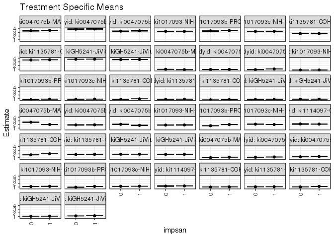

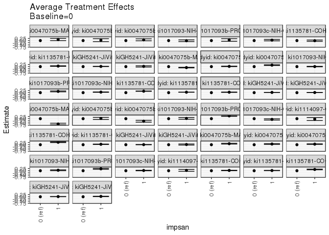

## Results Table

### Parameter: TSM

| agecat | studyid | country | intervention_level | baseline_level | estimate | ci_lower | ci_upper |
| --- | --- | --- | --- | --- | --- | --- | --- |
| 0-3 months | ki0047075b-MAL-ED | BANGLADESH | 0 | NA | 3.4292734 | 3.3198525 | 3.5386942 |
| 0-3 months | ki0047075b-MAL-ED | BANGLADESH | 1 | NA | 3.5534710 | 3.4882207 | 3.6187213 |
| 0-3 months | ki0047075b-MAL-ED | INDIA | 0 | NA | 3.8886109 | 3.7792668 | 3.9979550 |
| 0-3 months | ki0047075b-MAL-ED | INDIA | 1 | NA | 3.9386101 | 3.8289604 | 4.0482597 |
| 0-3 months | ki0047075b-MAL-ED | PERU | 0 | NA | 3.3367159 | 3.2699116 | 3.4035203 |
| 0-3 months | ki0047075b-MAL-ED | PERU | 1 | NA | 3.4246695 | 3.3318998 | 3.5174392 |
| 0-3 months | ki1017093-NIH-Birth | BANGLADESH | 0 | NA | 3.2866988 | 3.2243309 | 3.3490666 |
| 0-3 months | ki1017093-NIH-Birth | BANGLADESH | 1 | NA | 3.2712186 | 3.1899950 | 3.3524423 |
| 0-3 months | ki1017093b-PROVIDE | BANGLADESH | 0 | NA | 3.4140786 | 3.2667741 | 3.5613831 |
| 0-3 months | ki1017093b-PROVIDE | BANGLADESH | 1 | NA | 3.4859585 | 3.4455348 | 3.5263822 |
| 0-3 months | ki1017093c-NIH-Crypto | BANGLADESH | 0 | NA | 3.2625989 | 3.1899767 | 3.3352212 |
| 0-3 months | ki1017093c-NIH-Crypto | BANGLADESH | 1 | NA | 3.3136739 | 3.2724924 | 3.3548554 |
| 0-3 months | ki1135781-COHORTS | GUATEMALA | 0 | NA | 2.6584282 | 2.6020554 | 2.7148009 |
| 0-3 months | ki1135781-COHORTS | GUATEMALA | 1 | NA | 2.6477084 | 2.5832099 | 2.7122070 |
| 0-3 months | ki1135781-COHORTS | INDIA | 0 | NA | 3.5087166 | 3.4883567 | 3.5290766 |
| 0-3 months | ki1135781-COHORTS | INDIA | 1 | NA | 3.5722324 | 3.5469160 | 3.5975489 |
| 0-3 months | kiGH5241-JiVitA-3 | BANGLADESH | 0 | NA | 3.7060484 | 3.6900512 | 3.7220455 |
| 0-3 months | kiGH5241-JiVitA-3 | BANGLADESH | 1 | NA | 3.7269778 | 3.7155302 | 3.7384253 |
| 0-3 months | kiGH5241-JiVitA-4 | BANGLADESH | 0 | NA | 3.6232893 | 3.5612377 | 3.6853409 |
| 0-3 months | kiGH5241-JiVitA-4 | BANGLADESH | 1 | NA | 3.6499025 | 3.6145452 | 3.6852597 |
| 3-6 months | ki0047075b-MAL-ED | BANGLADESH | 0 | NA | 2.6072576 | 2.5328656 | 2.6816495 |
| 3-6 months | ki0047075b-MAL-ED | BANGLADESH | 1 | NA | 1.9869865 | 1.9333993 | 2.0405738 |
| 3-6 months | ki0047075b-MAL-ED | INDIA | 0 | NA | 1.8643717 | 1.7815779 | 1.9471654 |
| 3-6 months | ki0047075b-MAL-ED | INDIA | 1 | NA | 1.8953711 | 1.8060981 | 1.9846440 |
| 3-6 months | ki0047075b-MAL-ED | PERU | 0 | NA | 2.0410828 | 1.9703439 | 2.1118217 |
| 3-6 months | ki0047075b-MAL-ED | PERU | 1 | NA | 1.7485122 | 1.6654047 | 1.8316196 |
| 3-6 months | ki1017093-NIH-Birth | BANGLADESH | 0 | NA | 1.8256641 | 1.7679698 | 1.8833583 |
| 3-6 months | ki1017093-NIH-Birth | BANGLADESH | 1 | NA | 1.8536426 | 1.7746355 | 1.9326496 |
| 3-6 months | ki1017093b-PROVIDE | BANGLADESH | 0 | NA | 1.6444816 | 1.5988223 | 1.6901409 |
| 3-6 months | ki1017093b-PROVIDE | BANGLADESH | 1 | NA | 1.9677304 | 1.9317623 | 2.0036985 |

[output cut: 58 more lines]

### Parameter: E(Y)

| agecat | studyid | country | intervention_level | baseline_level | estimate | ci_lower | ci_upper |
| --- | --- | --- | --- | --- | --- | --- | --- |
| 0-3 months | ki0047075b-MAL-ED | BANGLADESH | NA | NA | 3.5715787 | 3.5085237 | 3.6346338 |
| 0-3 months | ki0047075b-MAL-ED | INDIA | NA | NA | 3.5636532 | 3.4868354 | 3.6404709 |
| 0-3 months | ki0047075b-MAL-ED | PERU | NA | NA | 3.3357751 | 3.2717728 | 3.3997775 |
| 0-3 months | ki1017093-NIH-Birth | BANGLADESH | NA | NA | 3.3129255 | 3.2581305 | 3.3677204 |
| 0-3 months | ki1017093b-PROVIDE | BANGLADESH | NA | NA | 3.4826706 | 3.4434873 | 3.5218539 |
| 0-3 months | ki1017093c-NIH-Crypto | BANGLADESH | NA | NA | 3.3065332 | 3.2680709 | 3.3449955 |
| 0-3 months | ki1135781-COHORTS | GUATEMALA | NA | NA | 2.6469683 | 2.5917793 | 2.7021572 |
| 0-3 months | ki1135781-COHORTS | INDIA | NA | NA | 3.5326234 | 3.5157525 | 3.5494943 |
| 0-3 months | kiGH5241-JiVitA-3 | BANGLADESH | NA | NA | 3.7184254 | 3.7080855 | 3.7287653 |
| 0-3 months | kiGH5241-JiVitA-4 | BANGLADESH | NA | NA | 3.6386177 | 3.6075243 | 3.6697112 |
| 3-6 months | ki0047075b-MAL-ED | BANGLADESH | NA | NA | 1.9280462 | 1.8787523 | 1.9773401 |
| 3-6 months | ki0047075b-MAL-ED | INDIA | NA | NA | 1.8786477 | 1.8179085 | 1.9393869 |
| 3-6 months | ki0047075b-MAL-ED | PERU | NA | NA | 2.0202782 | 1.9544261 | 2.0861304 |
| 3-6 months | ki1017093-NIH-Birth | BANGLADESH | NA | NA | 1.8326915 | 1.7846731 | 1.8807099 |
| 3-6 months | ki1017093b-PROVIDE | BANGLADESH | NA | NA | 1.9662173 | 1.9311292 | 2.0013054 |
| 3-6 months | ki1017093c-NIH-Crypto | BANGLADESH | NA | NA | 2.0027540 | 1.9667312 | 2.0387768 |
| 3-6 months | ki1114097-CONTENT | PERU | NA | NA | 2.0841841 | 2.0362519 | 2.1321163 |
| 3-6 months | ki1135781-COHORTS | GUATEMALA | NA | NA | 1.7541195 | 1.7166655 | 1.7915734 |
| 3-6 months | ki1135781-COHORTS | INDIA | NA | NA | 1.8572103 | 1.8432112 | 1.8712094 |
| 3-6 months | kiGH5241-JiVitA-3 | BANGLADESH | NA | NA | 1.9202048 | 1.9097374 | 1.9306722 |
| 3-6 months | kiGH5241-JiVitA-4 | BANGLADESH | NA | NA | 1.8987567 | 1.8688242 | 1.9286892 |
| 6-12 months | ki0047075b-MAL-ED | BANGLADESH | NA | NA | 1.1143928 | 1.0896103 | 1.1391753 |
| 6-12 months | ki0047075b-MAL-ED | INDIA | NA | NA | 1.1214380 | 1.0928994 | 1.1499767 |
| 6-12 months | ki0047075b-MAL-ED | PERU | NA | NA | 1.2081918 | 1.1749797 | 1.2414040 |
| 6-12 months | ki1017093-NIH-Birth | BANGLADESH | NA | NA | 1.1679344 | 1.1454934 | 1.1903754 |
| 6-12 months | ki1017093b-PROVIDE | BANGLADESH | NA | NA | 1.1737150 | 1.1564064 | 1.1910236 |
| 6-12 months | ki1017093c-NIH-Crypto | BANGLADESH | NA | NA | 1.2296139 | 1.2120656 | 1.2471621 |
| 6-12 months | ki1114097-CONTENT | PERU | NA | NA | 1.3010517 | 1.2719491 | 1.3301542 |
| 6-12 months | ki1135781-COHORTS | GUATEMALA | NA | NA | 1.0143216 | 0.9941032 | 1.0345401 |
| 6-12 months | ki1135781-COHORTS | INDIA | NA | NA | 1.0832753 | 1.0736142 | 1.0929363 |
| 6-12 months | ki1135781-COHORTS | PHILIPPINES | NA | NA | 1.0498206 | 1.0308068 | 1.0688345 |
| 6-12 months | kiGH5241-JiVitA-3 | BANGLADESH | NA | NA | 1.1069669 | 1.1002186 | 1.1137153 |
| 6-12 months | kiGH5241-JiVitA-4 | BANGLADESH | NA | NA | 1.2031603 | 1.1927643 | 1.2135564 |
| 12-24 months | ki0047075b-MAL-ED | BANGLADESH | NA | NA | 0.8459764 | 0.8299714 | 0.8619814 |
| 12-24 months | ki0047075b-MAL-ED | INDIA | NA | NA | 0.8815607 | 0.8644247 | 0.8986966 |
| 12-24 months | ki0047075b-MAL-ED | PERU | NA | NA | 0.8469084 | 0.8260658 | 0.8677509 |
| 12-24 months | ki1017093-NIH-Birth | BANGLADESH | NA | NA | 0.7513013 | 0.7366996 | 0.7659029 |
| 12-24 months | ki1017093b-PROVIDE | BANGLADESH | NA | NA | 0.8575399 | 0.8455203 | 0.8695594 |
| 12-24 months | ki1017093c-NIH-Crypto | BANGLADESH | NA | NA | 0.8757546 | 0.8638195 | 0.8876896 |
| 12-24 months | ki1135781-COHORTS | GUATEMALA | NA | NA | 0.7787104 | 0.7669110 | 0.7905098 |
| 12-24 months | ki1135781-COHORTS | INDIA | NA | NA | 0.8192911 | 0.8134060 | 0.8251761 |
| 12-24 months | ki1135781-COHORTS | PHILIPPINES | NA | NA | 0.6772522 | 0.6655435 | 0.6889610 |
| 12-24 months | kiGH5241-JiVitA-3 | BANGLADESH | NA | NA | 0.7967041 | 0.7913867 | 0.8020215 |
| 12-24 months | kiGH5241-JiVitA-4 | BANGLADESH | NA | NA | 0.8492263 | 0.8437928 | 0.8546597 |

### Parameter: ATE

| agecat | studyid | country | intervention_level | baseline_level | estimate | ci_lower | ci_upper |
| --- | --- | --- | --- | --- | --- | --- | --- |
| 0-3 months | ki0047075b-MAL-ED | BANGLADESH | 0 | 0 | 0.0000000 | 0.0000000 | 0.0000000 |
| 0-3 months | ki0047075b-MAL-ED | BANGLADESH | 1 | 0 | 0.1241976 | -0.0031250 | 0.2515203 |
| 0-3 months | ki0047075b-MAL-ED | INDIA | 0 | 0 | 0.0000000 | 0.0000000 | 0.0000000 |
| 0-3 months | ki0047075b-MAL-ED | INDIA | 1 | 0 | 0.0499992 | -0.1211692 | 0.2211675 |
| 0-3 months | ki0047075b-MAL-ED | PERU | 0 | 0 | 0.0000000 | 0.0000000 | 0.0000000 |
| 0-3 months | ki0047075b-MAL-ED | PERU | 1 | 0 | 0.0879536 | -0.0264226 | 0.2023298 |
| 0-3 months | ki1017093-NIH-Birth | BANGLADESH | 0 | 0 | 0.0000000 | 0.0000000 | 0.0000000 |
| 0-3 months | ki1017093-NIH-Birth | BANGLADESH | 1 | 0 | -0.0154801 | -0.1128194 | 0.0818592 |
| 0-3 months | ki1017093b-PROVIDE | BANGLADESH | 0 | 0 | 0.0000000 | 0.0000000 | 0.0000000 |
| 0-3 months | ki1017093b-PROVIDE | BANGLADESH | 1 | 0 | 0.0718799 | -0.0808305 | 0.2245903 |
| 0-3 months | ki1017093c-NIH-Crypto | BANGLADESH | 0 | 0 | 0.0000000 | 0.0000000 | 0.0000000 |
| 0-3 months | ki1017093c-NIH-Crypto | BANGLADESH | 1 | 0 | 0.0510749 | -0.0323923 | 0.1345422 |
| 0-3 months | ki1135781-COHORTS | GUATEMALA | 0 | 0 | 0.0000000 | 0.0000000 | 0.0000000 |
| 0-3 months | ki1135781-COHORTS | GUATEMALA | 1 | 0 | -0.0107197 | -0.0900097 | 0.0685702 |
| 0-3 months | ki1135781-COHORTS | INDIA | 0 | 0 | 0.0000000 | 0.0000000 | 0.0000000 |
| 0-3 months | ki1135781-COHORTS | INDIA | 1 | 0 | 0.0635158 | 0.0319491 | 0.0950825 |
| 0-3 months | kiGH5241-JiVitA-3 | BANGLADESH | 0 | 0 | 0.0000000 | 0.0000000 | 0.0000000 |
| 0-3 months | kiGH5241-JiVitA-3 | BANGLADESH | 1 | 0 | 0.0209294 | 0.0035957 | 0.0382630 |
| 0-3 months | kiGH5241-JiVitA-4 | BANGLADESH | 0 | 0 | 0.0000000 | 0.0000000 | 0.0000000 |
| 0-3 months | kiGH5241-JiVitA-4 | BANGLADESH | 1 | 0 | 0.0266131 | -0.0449363 | 0.0981626 |
| 3-6 months | ki0047075b-MAL-ED | BANGLADESH | 0 | 0 | 0.0000000 | 0.0000000 | 0.0000000 |
| 3-6 months | ki0047075b-MAL-ED | BANGLADESH | 1 | 0 | -0.6202711 | -0.7168822 | -0.5236600 |
| 3-6 months | ki0047075b-MAL-ED | INDIA | 0 | 0 | 0.0000000 | 0.0000000 | 0.0000000 |
| 3-6 months | ki0047075b-MAL-ED | INDIA | 1 | 0 | 0.0309994 | -0.0907564 | 0.1527551 |
| 3-6 months | ki0047075b-MAL-ED | PERU | 0 | 0 | 0.0000000 | 0.0000000 | 0.0000000 |
| 3-6 months | ki0047075b-MAL-ED | PERU | 1 | 0 | -0.2925707 | -0.4015979 | -0.1835434 |
| 3-6 months | ki1017093-NIH-Birth | BANGLADESH | 0 | 0 | 0.0000000 | 0.0000000 | 0.0000000 |
| 3-6 months | ki1017093-NIH-Birth | BANGLADESH | 1 | 0 | 0.0279785 | -0.0690353 | 0.1249923 |
| 3-6 months | ki1017093b-PROVIDE | BANGLADESH | 0 | 0 | 0.0000000 | 0.0000000 | 0.0000000 |
| 3-6 months | ki1017093b-PROVIDE | BANGLADESH | 1 | 0 | 0.3232488 | 0.2691729 | 0.3773247 |

[output cut: 58 more lines]